# Data Analyses and Visualization

##Purpose

The purpose of this page is to document the analyses of the redcedar adaptation network data.

Merged data set was downloaded from adaptation-data-merged.csv. Analyses were completed to explore the relationship between origin seed zone and two continuous and one binary variable representing tree health.

- Continuous response variables:
  - Tree diameter (mm)
  - Tree height (cm)
- Binary response variable:
  - Tree health, classified as “Alive” or “Dead”

Two identical analyses were completed to determine whether wildlife tree browsing activity posed as a confounded variable in our experimental design as levels of browsing varied from none to heavily browsed across each planting site. The first set of analyses completely excluded browsed trees from the data set if the trees were ever browsed across all measurement years. The second set of analyses included every tree regardless of browsing level.

### Load packages

```r
library(tidyverse)
library(kableExtra)
library(patchwork)
library(zoo)
library(readxl)
library(knitr)
library(lme4)
library(lmerTest)
library(readr)
library(gridExtra)
library(ggpubr)
library(cowplot)
```

### Import data

```r
trees <- read.csv("https://raw.githubusercontent.com/zarigal/adaptation/refs/heads/main/data/adaptation-data-merged.csv")
#if offline - data <-read.csv("data/adaptation-data-merged.csv")
```

## Data not including browsed

The following plots, tables, and analysis completely excludes all years’ measurements from trees that had any instance of wildlife browsing observed during re-measurements.

```r
trees.no.browse <- trees %>%
  group_by(Tree.Number, Site, Seed.Zone) %>%
  filter(!any(Elk.Browse == "Y")) %>% ungroup()

treesno.wide <- trees.no.browse %>% pivot_wider(
    id_cols = c(Tree.Number, Site, Seed.Zone, New.Tree.Number),
    names_from = Measurement.Year,
    values_from = c(Tree.Height..cm., Tree.Diameter..mm.),
    names_glue = "{.value}_{Measurement.Year}")

treesno.wide.growth <- treesno.wide %>% mutate(y1.height.growth = Tree.Height..cm._2023-Tree.Height..cm._2022, y2.height.growth = Tree.Height..cm._2024-Tree.Height..cm._2023, y3.height.growth = Tree.Height..cm._2025-Tree.Height..cm._2024, y4.height.growth = Tree.Height..cm._2026 - Tree.Height..cm._2025, y1.diameter.growth = Tree.Diameter..mm._2023-Tree.Diameter..mm._2022, y2.diameter.growth = Tree.Diameter..mm._2024-Tree.Diameter..mm._2023, y3.diameter.growth = Tree.Diameter..mm._2025 - Tree.Diameter..mm._2024, y4.diameter.growth = Tree.Diameter..mm._2026 - Tree.Diameter..mm._2025, total.height.growth = Tree.Height..cm._2026-Tree.Height..cm._2022, total.diameter.growth = Tree.Diameter..mm._2026-Tree.Diameter..mm._2022)

treesno.wide.growth <- treesno.wide.growth %>% filter(!is.na(y1.height.growth)) %>% filter(!is.na(y2.height.growth)) %>% filter(!is.na(y3.height.growth)) %>% filter(!is.na(y4.height.growth)) %>%
  filter(!is.na(y1.diameter.growth)) %>% filter(!is.na(y2.diameter.growth)) %>% filter(!is.na(y3.diameter.growth)) %>% filter(!is.na(y4.diameter.growth))

treesno.wide.pos.total <- treesno.wide.growth %>% filter(total.height.growth>0 & total.diameter.growth>0)
treesno.wide.pos.y1 <- treesno.wide.growth %>% filter(y1.height.growth>0 & y1.diameter.growth>0)
treesno.wide.pos.y2 <- treesno.wide.growth %>% filter(y2.height.growth>0 & y2.diameter.growth>0)
treesno.wide.pos.y3 <- treesno.wide.growth %>% filter(y3.height.growth>0 & y3.diameter.growth>0)
treesno.wide.pos.y4 <- treesno.wide.growth %>% filter(y4.height.growth>0 & y4.diameter.growth>0)
treesno.wide.pos.all <- treesno.wide.growth %>% filter(y1.height.growth>0 & y1.diameter.growth>0 &
  y2.height.growth>0 & y2.diameter.growth>0 & y3.height.growth>0 & y3.diameter.growth>0 & y4.diameter.growth>0)
```

#### Number of Trees

The below table lists the number of trees that were remeasured in 2026 at each site, excluding outliers.

```r
Site.Summary <- treesno.wide.pos.all %>% group_by(Site,Seed.Zone) %>% summarize(n=n())
kable(Site.Summary[c(1,2,3)], col.names = c("Site", "Seed Zone", "Number of Trees")) %>% kable_material(c("striped", "hover","condensed"))
```

| Site | Seed Zone | Number of Trees |
| --- | --- | --- |
| Renton | OR | 11 |
| Renton | WA | 31 |
| Seattle | OR | 23 |
| Seattle | WA | 27 |
| Swan Creek | OR | 20 |
| Swan Creek | WA | 13 |

#### Mean Height and Diameter Increase

The below table lists mean height and diameter increases between seed zones.

```r
treesno.summary <- treesno.wide.pos.all %>% group_by(Seed.Zone)  %>% summarize(n=n(),
meanno.height.2026=mean(Tree.Height..cm._2026),
meanno.diameter.2026=mean(Tree.Diameter..mm._2026),
meanno.y1.height.growth=mean(y1.height.growth,na.rm=TRUE),
meanno.y1.diameter.growth=mean(y1.diameter.growth,na.rm=TRUE),
meanno.y2.height.growth=mean(y2.height.growth,na.rm=TRUE),
meanno.y2.diameter.growth=mean(y2.diameter.growth,na.rm=TRUE),
meanno.y3.diameter.growth=mean(y3.diameter.growth,na.rm=TRUE),
meanno.y3.height.growth=mean(y3.height.growth,na.rm=TRUE),
meanno.y4.diameter.growth=mean(y4.diameter.growth,na.rm=TRUE),
meanno.y4.height.growth=mean(y4.height.growth,na.rm=TRUE),
meanno.total.height.growth=mean(total.height.growth,na.rm=TRUE),
meanno.total.diameter.growth=mean(total.diameter.growth,na.rm=TRUE))

kable(treesno.summary,col.names = c("Seed Zone", "Number of Trees", "2026 Mean Height (cm)", "2026 Mean Diameter (mm)", "Mean Year 1 Height Growth (cm)", "Mean Year 1 Diameter Growth (mm)", "Mean Year 2 Height Growth (cm)","Mean Year 2 Diameter Growth (mm)", "Mean Year 3 Height Growth (cm)","Mean Year 3 Diameter Growth (mm)", "Mean Year 4 Height Growth (cm)","Mean Year 4 Diameter Growth (mm)", "Total Mean Height Growth (cm)","Total Mean Diameter Growth (mm)"), digits = 2,format = "html",table.attr='class="scrollable-table"') %>% kable_material(c("striped", "hover","condensed")) %>% kable_styling(full_width = F) %>% scroll_box(height = "200px")
```

| Seed Zone | Number of Trees | 2026 Mean Height (cm) | 2026 Mean Diameter (mm) | Mean Year 1 Height Growth (cm) | Mean Year 1 Diameter Growth (mm) | Mean Year 2 Height Growth (cm) | Mean Year 2 Diameter Growth (mm) | Mean Year 3 Height Growth (cm) | Mean Year 3 Diameter Growth (mm) | Mean Year 4 Height Growth (cm) | Mean Year 4 Diameter Growth (mm) | Total Mean Height Growth (cm) | Total Mean Diameter Growth (mm) |
| --- | --- | --- | --- | --- | --- | --- | --- | --- | --- | --- | --- | --- | --- |
| OR | 54 | 172.52 | 40.64 | 9.16 | 4.06 | 33.80 | 11.84 | 10.34 | 34.22 | 5.44 | 11.61 | 88.79 | 31.68 |
| WA | 71 | 187.15 | 39.82 | 7.60 | 3.93 | 34.38 | 9.46 | 10.89 | 38.24 | 5.34 | 13.90 | 94.12 | 29.62 |

Trees from Oregon had a mean total height increase of 88.79 cm and trees from Washington had a mean total height increase of 94.12 cm.

#### Mean Increase by Site

The table below provides the same data, expect the means were calculated across seed zones and sites.

```r
treesno.summary.sites <- treesno.wide.pos.all %>% group_by(Site,Seed.Zone)  %>% summarize(
n=n(),
meanno.height.2026=mean(Tree.Height..cm._2026),
meanno.diameter.2026=mean(Tree.Diameter..mm._2026),
meanno.y1.height.growth=mean(y1.height.growth,na.rm=TRUE),
meanno.y1.diameter.growth=mean(y1.diameter.growth,na.rm=TRUE),
meanno.y2.height.growth=mean(y2.height.growth,na.rm=TRUE),
meanno.y2.diameter.growth=mean(y2.diameter.growth,na.rm=TRUE),
meanno.y3.diameter.growth=mean(y3.diameter.growth,na.rm=TRUE),
meanno.y3.height.growth=mean(y3.height.growth, na.rm = TRUE),
meanno.y4.diameter.growth=mean(y4.diameter.growth,na.rm=TRUE),
meanno.y4.height.growth=mean(y4.height.growth, na.rm = TRUE),
meanno.total.height.growth=mean(total.height.growth,na.rm=TRUE),
meanno.total.diameter.growth=mean(total.diameter.growth,na.rm=TRUE))

library(knitr)
kable(treesno.summary.sites, col.names = c("Site", "Seed Zone", "Number of Trees", "2025 Mean Height (cm)", "2025 Mean Diameter (mm)", "Mean Year 1 Height Growth (cm)", "Mean Year 1 Diameter Growth (mm)", "Mean Year 2 Height Growth (cm)","Mean Year 2 Diameter Growth (mm)", "Mean Year 3 Height Growth (cm)","Mean Year 3 Diameter Growth (mm)", "Mean Year 4 Height Growth (cm)","Mean Year 4 Diameter Growth (mm)","Total Mean Height Growth (cm)","Total Mean Diameter Growth (mm)"), digits = 2) %>% kable_material(c("striped", "hover","condensed")) %>% kable_styling(full_width = F) %>% scroll_box(height = "300px")
```

| Site | Seed Zone | Number of Trees | 2025 Mean Height (cm) | 2025 Mean Diameter (mm) | Mean Year 1 Height Growth (cm) | Mean Year 1 Diameter Growth (mm) | Mean Year 2 Height Growth (cm) | Mean Year 2 Diameter Growth (mm) | Mean Year 3 Height Growth (cm) | Mean Year 3 Diameter Growth (mm) | Mean Year 4 Height Growth (cm) | Mean Year 4 Diameter Growth (mm) | Total Mean Height Growth (cm) | Total Mean Diameter Growth (mm) |
| --- | --- | --- | --- | --- | --- | --- | --- | --- | --- | --- | --- | --- | --- | --- |
| Renton | OR | 11 | 151.82 | 25.50 | 8.45 | 2.84 | 25.00 | 2.95 | 4.04 | 26.55 | 5.71 | 6.36 | 66.36 | 15.52 |
| Renton | WA | 31 | 180.87 | 29.76 | 7.95 | 2.78 | 31.55 | 4.60 | 6.52 | 33.71 | 4.96 | 11.65 | 84.85 | 18.87 |
| Seattle | OR | 23 | 197.13 | 48.65 | 11.44 | 5.43 | 46.00 | 16.19 | 12.86 | 38.70 | 6.14 | 17.35 | 113.48 | 40.61 |
| Seattle | WA | 27 | 198.89 | 50.07 | 8.72 | 5.37 | 41.33 | 14.20 | 14.68 | 40.63 | 6.74 | 18.07 | 108.76 | 40.99 |
| Swan Creek | OR | 20 | 155.60 | 39.76 | 6.92 | 3.17 | 24.60 | 11.71 | 10.92 | 33.30 | 4.49 | 7.90 | 72.72 | 30.29 |
| Swan Creek | WA | 13 | 177.77 | 42.51 | 4.45 | 3.65 | 26.69 | 11.22 | 13.42 | 44.08 | 3.33 | 10.62 | 85.83 | 31.62 |

#### Tree Height Increase

The below plots show the distributions in increases in tree height for each seed zone.

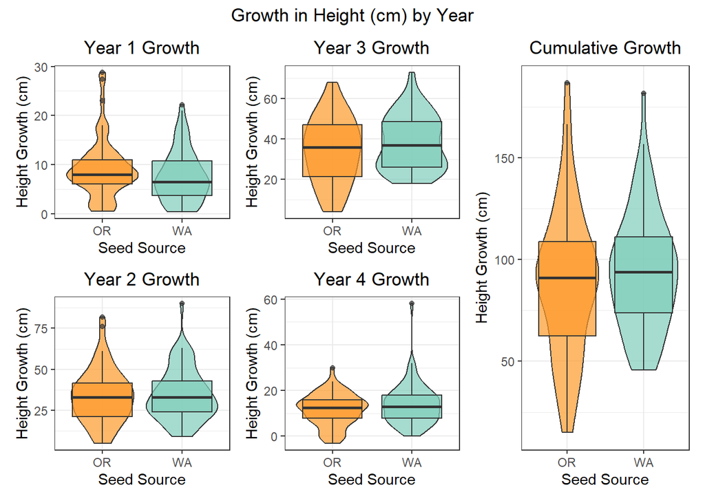

```r
P1 <- ggplot(treesno.wide.pos.all,aes(Seed.Zone,y1.height.growth,fill=Seed.Zone)) +geom_violin(alpha=0.7) +geom_boxplot(alpha=0.7) +theme_bw()+guides(fill="none") +scale_fill_manual(values=c("#fe9929", "#7fcdbb")) +labs(y= "Height Growth (cm)", x= "Seed Source",title="Year 1 Growth") + theme(plot.title = element_text(hjust = 0.5))
P2 <- ggplot(treesno.wide.pos.all,aes(Seed.Zone,y2.height.growth,fill=Seed.Zone)) +geom_violin(alpha=0.7) +geom_boxplot(alpha=0.7) +theme_bw()+guides(fill="none") +scale_fill_manual(values=c("#fe9929", "#7fcdbb")) +labs(y= "Height Growth (cm)",x= "Seed Source",title="Year 2 Growth") + theme(plot.title = element_text(hjust = 0.5))
P3 <- ggplot(treesno.wide.pos.all,aes(Seed.Zone,y3.height.growth,fill=Seed.Zone)) +geom_violin(alpha=0.7) +geom_boxplot(alpha=0.7) +theme_bw()+guides(fill="none") +scale_fill_manual(values=c("#fe9929", "#7fcdbb")) +labs(y= "Height Growth (cm)",x= "Seed Source",title="Year 3 Growth") + theme(plot.title = element_text(hjust = 0.5))
P4 <- ggplot(treesno.wide.pos.all,aes(Seed.Zone,y4.height.growth,fill=Seed.Zone)) +geom_violin(alpha=0.7) +geom_boxplot(alpha=0.7) +theme_bw()+guides(fill="none") +scale_fill_manual(values=c("#fe9929", "#7fcdbb")) +labs(y= "Height Growth (cm)",x= "Seed Source",title="Year 4 Growth") + theme(plot.title = element_text(hjust = 0.5))
P5 <- ggplot(treesno.wide.pos.all,aes(Seed.Zone,total.height.growth,fill=Seed.Zone)) +geom_violin(alpha=0.7) +geom_boxplot(alpha=0.7) +theme_bw()+guides(fill="none") +scale_fill_manual(values=c("#fe9929", "#7fcdbb")) +labs(y= "Height Growth (cm)",x= "Seed Source",title="Cumulative Growth") + theme(plot.title = element_text(hjust = 0.5))

plots1 <-plot_grid(P1, P2, align = "v", nrow = 2, ncol = 1, rel_heights = c(1/2,1/2))
plots2 <- plot_grid(P3, P4, align = "v", nrow = 2, ncol = 1, rel_heights = c(1/2,1/2))
plots3 <- plot_grid(P5, align = "v", nrow = 1, ncol = 1, rel_heights = 1)
plots <- plots1 + plots2 + plots3
plots + plot_annotation(title = "Growth in Height (cm) by Year", theme = theme(plot.title = element_text(hjust = 0.5)))
```

The below plot shows the distributions in cumulative increase in tree height for each seed zone and site.

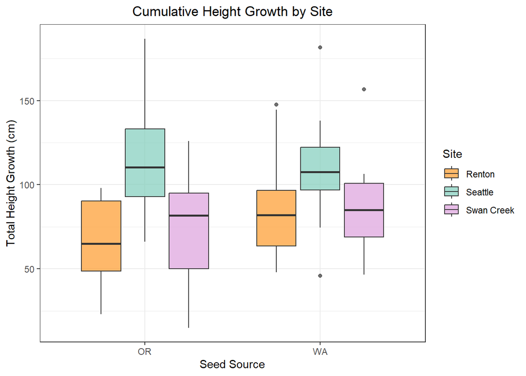

```r
ggplot(treesno.wide.pos.all,aes(Seed.Zone,total.height.growth,fill=Site)) +geom_boxplot(alpha=0.7) +theme_bw() +scale_fill_manual(values=c("#fe9929", "#7fcdbb", "#DDA0DD","#89CFF0")) + labs(y= "Total Height Growth (cm)",x= "Seed Source",title="Cumulative Height Growth by Site") + theme(plot.title = element_text(hjust = 0.5))
```

#### Tree Diameter Increase

The below plots show the distribution of growth in tree diameter for each seed zone.

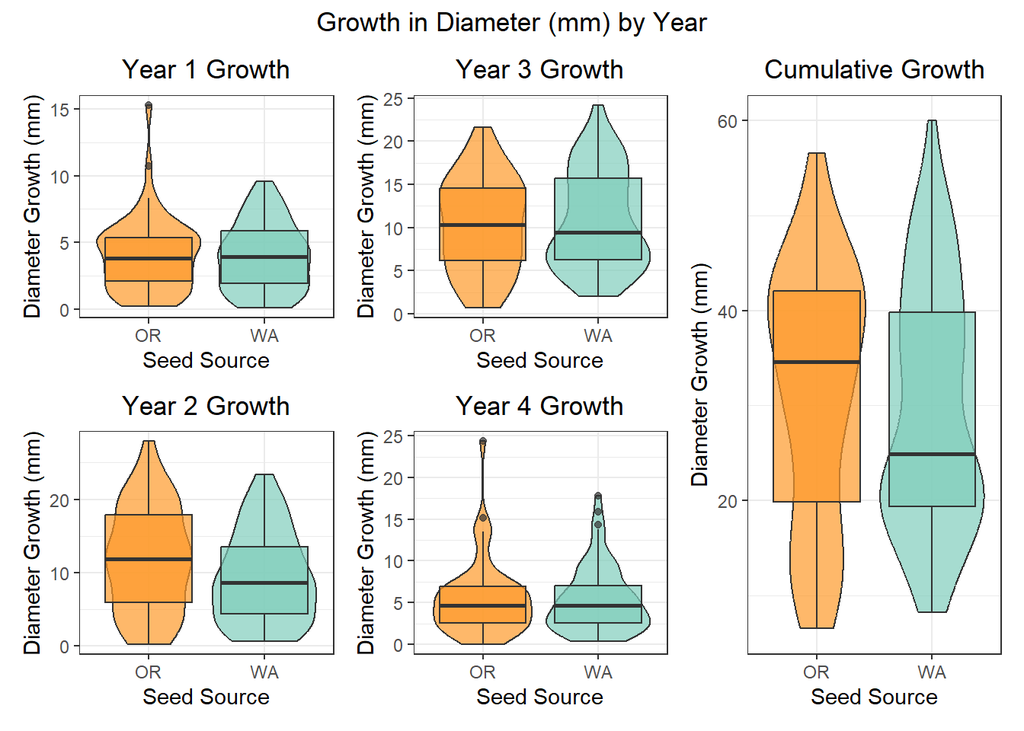

```r
P1 <- ggplot(treesno.wide.pos.all,aes(Seed.Zone,y1.diameter.growth,fill=Seed.Zone)) +geom_violin(alpha=0.7) +geom_boxplot(alpha=0.7) +theme_bw()+guides(fill="none") +scale_fill_manual(values=c("#fe9929", "#7fcdbb")) +labs(y= "Diameter Growth (mm)", x= "Seed Source",title="Year 1 Growth") + theme(plot.title = element_text(hjust = 0.5))
P2 <- ggplot(treesno.wide.pos.all,aes(Seed.Zone,y2.diameter.growth,fill=Seed.Zone)) +geom_violin(alpha=0.7) +geom_boxplot(alpha=0.7) +theme_bw()+guides(fill="none") +scale_fill_manual(values=c("#fe9929", "#7fcdbb")) +labs(y= "Diameter Growth (mm)",x= "Seed Source",title="Year 2 Growth") + theme(plot.title = element_text(hjust = 0.5))
P3 <- ggplot(treesno.wide.pos.all,aes(Seed.Zone,y3.diameter.growth,fill=Seed.Zone)) +geom_violin(alpha=0.7) +geom_boxplot(alpha=0.7) +theme_bw()+guides(fill="none") +scale_fill_manual(values=c("#fe9929", "#7fcdbb")) +labs(y= "Diameter Growth (mm)",x= "Seed Source",title="Year 3 Growth") + theme(plot.title = element_text(hjust = 0.5))
P4 <- ggplot(treesno.wide.pos.all,aes(Seed.Zone,y4.diameter.growth,fill=Seed.Zone)) +geom_violin(alpha=0.7) +geom_boxplot(alpha=0.7) +theme_bw()+guides(fill="none") +scale_fill_manual(values=c("#fe9929", "#7fcdbb")) +labs(y= "Diameter Growth (mm)",x= "Seed Source",title="Year 4 Growth") + theme(plot.title = element_text(hjust = 0.5))
P5 <- ggplot(treesno.wide.pos.all,aes(Seed.Zone,total.diameter.growth,fill=Seed.Zone)) +geom_violin(alpha=0.7) +geom_boxplot(alpha=0.7) +theme_bw()+guides(fill="none") +scale_fill_manual(values=c("#fe9929", "#7fcdbb")) +labs(y= "Diameter Growth (mm)",x= "Seed Source",title="Cumulative Growth") + theme(plot.title = element_text(hjust = 0.5))

plots1 <-plot_grid(P1, P2, align = "v", nrow = 2, ncol = 1, rel_heights = c(1/2,1/2))
plots2 <- plot_grid(P3, P4, align = "v", nrow = 2, ncol = 1, rel_heights = c(1/2,1/2))
plots3 <- plot_grid(P5, align = "v", nrow = 1, ncol = 1, rel_heights = 1)
plots <- plots1 + plots2 + plots3
plots + plot_annotation(title = "Growth in Diameter (mm) by Year", theme = theme(plot.title = element_text(hjust = 0.5)))
```

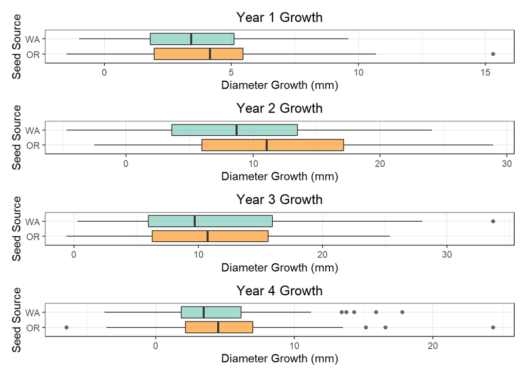

```r
G1 <- ggplot(treesno.wide.growth,aes(y1.diameter.growth,Seed.Zone,fill=Seed.Zone))+geom_boxplot(alpha=0.7) +theme_bw() +guides(fill="none") +scale_fill_manual(values=c("#fe9929", "#7fcdbb")) +labs(x= "Diameter Growth (mm)",y= "Seed Source",title="Year 1 Growth") + theme(plot.title = element_text(hjust = 0.5))
G2 <- ggplot(treesno.wide.growth,aes(y2.diameter.growth,Seed.Zone,fill=Seed.Zone))+geom_boxplot(alpha=0.7) +theme_bw() +guides(fill="none") +scale_fill_manual(values=c("#fe9929", "#7fcdbb")) +labs(x= "Diameter Growth (mm)",y= "Seed Source",title="Year 2 Growth") + theme(plot.title = element_text(hjust = 0.5))
G3 <- ggplot(treesno.wide.growth,aes(y3.diameter.growth,Seed.Zone,fill=Seed.Zone))+geom_boxplot(alpha=0.7) +theme_bw() +guides(fill="none") +scale_fill_manual(values=c("#fe9929", "#7fcdbb")) +labs(x= "Diameter Growth (mm)",y= "Seed Source",title="Year 3 Growth") + theme(plot.title = element_text(hjust = 0.5))
G4 <- ggplot(treesno.wide.growth,aes(y4.diameter.growth,Seed.Zone,fill=Seed.Zone))+geom_boxplot(alpha=0.7) +theme_bw() +guides(fill="none") +scale_fill_manual(values=c("#fe9929", "#7fcdbb")) +labs(x= "Diameter Growth (mm)",y= "Seed Source",title="Year 4 Growth") + theme(plot.title = element_text(hjust = 0.5))

G1 / G2/ G3 / G4
```

The below plots show the distributions in increases in tree diameter for each seed zone and site.

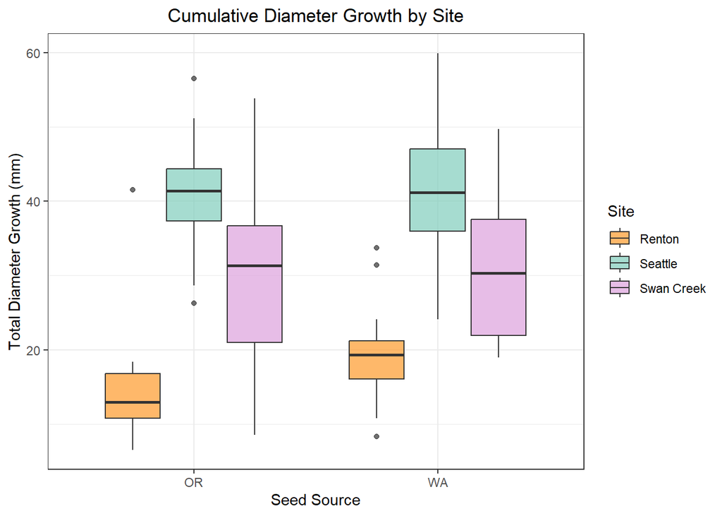

```r
ggplot(treesno.wide.pos.all,aes(Seed.Zone,total.diameter.growth,fill=Site)) +geom_boxplot(alpha=0.7) +theme_bw() +scale_fill_manual(values=c("#fe9929", "#7fcdbb", "#DDA0DD","#89CFF0")) + labs(y= "Total Diameter Growth (mm)",x= "Seed Source",title="Cumulative Diameter Growth by Site") + theme(plot.title = element_text(hjust = 0.5))
```

#### Mortality

The below plot shows the number of trees that fall under each Health condition: alive, dead, or missing.

- Note: Missing trees are classified as trees that were not found during remeasurements any time from 2023-2026.

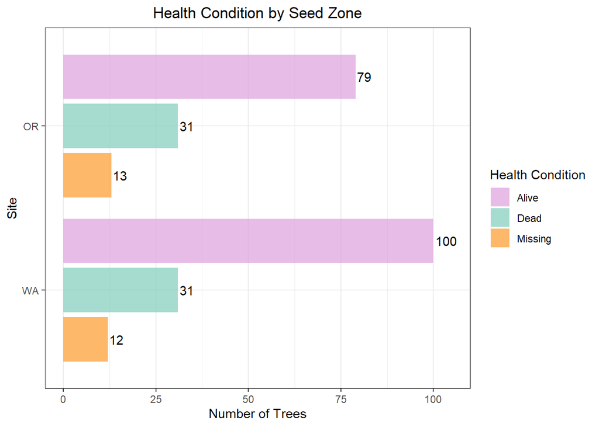

```r
treesno.condition.zone <- trees.no.browse %>% filter(Site != "Tomanamus") %>% group_by(Seed.Zone, Final.Health) %>% summarize(n=n_distinct(Temp.Tree.Number)) %>% filter(Final.Health!="NA")

ggplot(treesno.condition.zone,aes(x = reorder(Seed.Zone, -n),n,fill=Final.Health))+geom_col(alpha=0.7,position = position_dodge2(preserve = "single",reverse=TRUE))+theme_bw()+coord_flip()+ scale_y_continuous(breaks = c(0,25,50,75,100,125,150),expand = expansion(mult = c(0.05, 0.1))) +scale_fill_manual(values=c( "#DDA0DD","#7fcdbb","#fe9929","#CC79A7"))+labs(x="Site",y="Number of Trees",title ="Health Condition by Seed Zone", fill="Health Condition") +geom_text(aes(label=n,group=Final.Health),position = position_dodge2(width=0.9,preserve = "single",reverse=TRUE),hjust=-0.1) + theme(plot.title = element_text(hjust = 0.5))
```

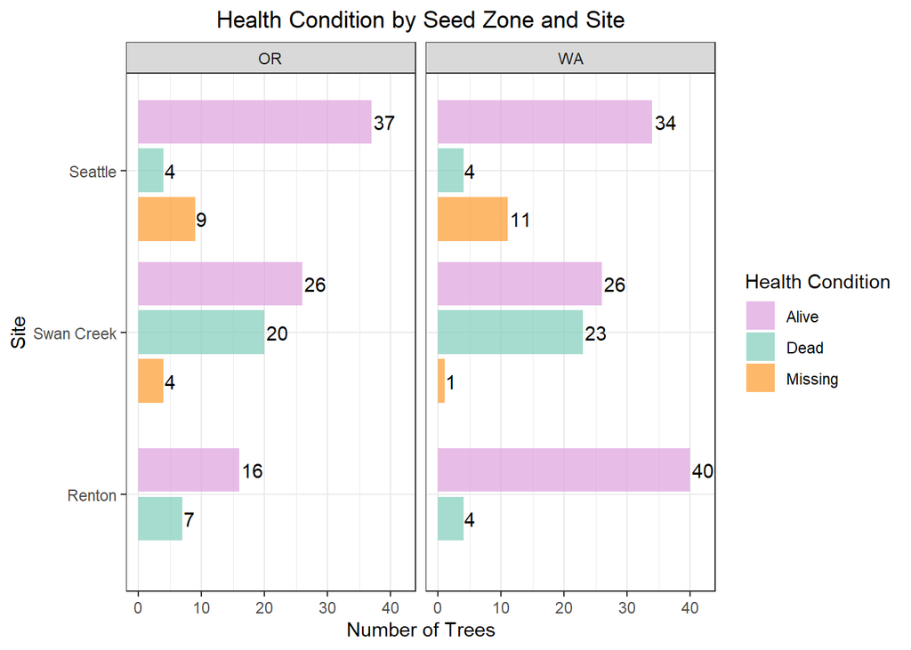

```r
treesno.condition <- trees.no.browse %>% group_by(Site, Seed.Zone,Final.Health) %>% summarize(n=n_distinct(Temp.Tree.Number)) %>% filter(Final.Health!="NA") %>% filter(Site != "Tomanamus")

treesno.condition$Final.Health <- factor(treesno.condition$Final.Health, levels=c('Alive','Dead','Dying','Missing'))

ggplot(treesno.condition,aes(x = reorder(Site, -n),n,fill=Final.Health))+facet_wrap(~Seed.Zone)+geom_col(alpha=0.7,position = position_dodge2(preserve = "single",reverse=TRUE))+theme_bw()+coord_flip() + scale_y_continuous(expand = expansion(mult = c(0.05, 0.1))) +scale_fill_manual(values=c( "#DDA0DD","#7fcdbb","#fe9929","#CC79A7"))+labs(x="Site",y="Number of Trees", title = "Health Condition by Seed Zone and Site",fill="Health Condition") +geom_text(aes(label=n,group=Final.Health),position = position_dodge2(width=0.9,preserve = "single",reverse=TRUE),hjust=-0.1) + theme(plot.title = element_text(hjust = 0.5))
```

## Data including browsed

The following plots, tables, and analysis includes all years’ measurements trees browsed by wildlife.

```r
trees$Site <- as.factor(trees$Site)
trees$Seed.Zone <-as.factor(trees$Seed.Zone)
trees$Health <- as.factor(trees$Health)

trees.wide <- trees %>% pivot_wider(
    id_cols = c(Tree.Number, Site, Seed.Zone, New.Tree.Number),
    names_from = Measurement.Year,
    values_from = c(Tree.Height..cm., Tree.Diameter..mm.),
    names_glue = "{.value}_{Measurement.Year}")

trees.wide.growth <- trees.wide %>% mutate(y1.height.growth = Tree.Height..cm._2023-Tree.Height..cm._2022, y2.height.growth = Tree.Height..cm._2024-Tree.Height..cm._2023, y3.height.growth = Tree.Height..cm._2025-Tree.Height..cm._2024, y4.height.growth = Tree.Height..cm._2026 - Tree.Height..cm._2025, y1.diameter.growth = Tree.Diameter..mm._2023-Tree.Diameter..mm._2022, y2.diameter.growth = Tree.Diameter..mm._2024-Tree.Diameter..mm._2023, y3.diameter.growth = Tree.Diameter..mm._2025 - Tree.Diameter..mm._2024, y4.diameter.growth = Tree.Diameter..mm._2026 - Tree.Diameter..mm._2025, total.height.growth = Tree.Height..cm._2026-Tree.Height..cm._2022, total.diameter.growth = Tree.Diameter..mm._2026-Tree.Diameter..mm._2022)

trees.wide.growth <- trees.wide.growth %>% filter(!is.na(y1.height.growth)) %>% filter(!is.na(y2.height.growth)) %>% filter(!is.na(y3.height.growth)) %>% filter(!is.na(y4.height.growth)) %>%
  filter(!is.na(y1.diameter.growth)) %>% filter(!is.na(y2.diameter.growth)) %>% filter(!is.na(y3.diameter.growth)) %>% filter(!is.na(y4.diameter.growth))

#trees.wide.pos.total <- trees.wide.growth %>% filter(total.height.growth>0 & total.diameter.growth>0)
#trees.wide.pos.y1 <- trees.wide.growth %>% filter(y1.height.growth>0 & y1.diameter.growth>0)
#trees.wide.pos.y2 <- trees.wide.growth %>% filter(y2.height.growth>0 & y2.diameter.growth>0)
#trees.wide.pos.y3 <- trees.wide.growth %>% filter(y3.height.growth>0 & y3.diameter.growth>0)
#trees.wide.pos.y4 <- trees.wide.growth %>% filter(y4.height.growth>0 & y4.diameter.growth>0)
#trees.wide.growth <- trees.wide.growth %>% filter(y1.height.growth>0 & y1.diameter.growth>0 &
#  y2.height.growth>0 & y2.diameter.growth>0 & y3.height.growth>0 & y3.diameter.growth>0 &
#    y4.diameter.growth>0 & y4.height.growth>0)

## above code removes observations with negative growth year to year (from browsing)
```

##### Number of Trees

The below table lists the number of trees that were remeasured in 2026 at each site, excluding outliers.

```r
Site.Summary <- trees.wide.growth %>% filter(Site != "Tomanamus") %>% group_by(Site,Seed.Zone) %>% summarize(n=n())
kable(Site.Summary[c(1,2,3)], col.names = c("Site", "Seed Zone", "Number of Trees")) %>% kable_material(c("striped", "hover","condensed"))
```

| Site | Seed Zone | Number of Trees |
| --- | --- | --- |
| Renton | OR | 36 |
| Renton | WA | 46 |
| Seattle | OR | 36 |
| Seattle | WA | 35 |
| Swan Creek | OR | 25 |
| Swan Creek | WA | 21 |

##### Mean Height and Diameter Increase

The below table lists mean height and diameter increases between seed zones.

```r
trees.summary <- trees.wide.growth %>% group_by(Seed.Zone)  %>% summarize(
n=n(),
mean.height.2026=mean(Tree.Height..cm._2026),
mean.diameter.2026=mean(Tree.Diameter..mm._2026),
mean.y1.height.growth=mean(y1.height.growth,na.rm=TRUE),
mean.y1.diameter.growth=mean(y1.diameter.growth,na.rm=TRUE),
mean.y2.height.growth=mean(y2.height.growth,na.rm=TRUE),
mean.y2.diameter.growth=mean(y2.diameter.growth,na.rm=TRUE),
mean.y3.height.growth=mean(y3.height.growth,na.rm=TRUE),
mean.y3.diameter.growth=mean(y3.diameter.growth,na.rm=TRUE),
mean.y4.height.growth=mean(y4.height.growth,na.rm=TRUE),
mean.y4.diameter.growth=mean(y4.diameter.growth,na.rm=TRUE),
mean.total.height.growth=mean(total.height.growth,na.rm=TRUE),
mean.total.diameter.growth=mean(total.diameter.growth,na.rm=TRUE))


kable(trees.summary,col.names = c("Seed Zone", "Number of Trees", "2026 Mean Height (cm)", "2026 Mean Diameter (mm)", "Mean Year 1 Height Growth (cm)", "Mean Year 1 Diameter Growth (mm)", "Mean Year 2 Height Growth (cm)","Mean Year 2 Diameter Growth (mm)", "Mean Year 3 Height Growth (cm)","Mean Year 3 Diameter Growth (mm)", "Mean Year 4 Height Growth (cm)","Mean Year 4 Diameter Growth (mm)","Total Mean Height Growth (cm)","Total Mean Diameter Growth (mm)"), digits = 2,format = "html", table.attr='class="scrollable-table"') %>% kable_material(c("striped", "hover","condensed")) %>% kable_styling(full_width = F) %>% scroll_box(height = "300px")
```

| Seed Zone | Number of Trees | 2026 Mean Height (cm) | 2026 Mean Diameter (mm) | Mean Year 1 Height Growth (cm) | Mean Year 1 Diameter Growth (mm) | Mean Year 2 Height Growth (cm) | Mean Year 2 Diameter Growth (mm) | Mean Year 3 Height Growth (cm) | Mean Year 3 Diameter Growth (mm) | Mean Year 4 Height Growth (cm) | Mean Year 4 Diameter Growth (mm) | Total Mean Height Growth (cm) | Total Mean Diameter Growth (mm) |
| --- | --- | --- | --- | --- | --- | --- | --- | --- | --- | --- | --- | --- | --- |
| OR | 97 | 149.6 | 35.18 | 7.34 | 3.54 | 19.10 | 9.46 | 29.58 | 9.02 | 10.94 | 4.14 | 66.96 | 26.16 |
| WA | 102 | 177.8 | 37.78 | 6.47 | 3.45 | 30.38 | 8.94 | 35.26 | 10.77 | 13.07 | 4.23 | 85.19 | 27.39 |

Trees from Oregon had a mean total height increase of 66.96 cm and trees from Washington had a mean total height increase of 85.19 cm.

##### Mean Increase by Site

The table below provides the same data, expect the means were calculated across seed zones and sites.

```r
trees.summary.sites <- trees.wide.growth %>% group_by(Site,Seed.Zone)  %>% summarize(
n=n(),
mean.height.2026=mean(Tree.Height..cm._2026),
mean.diameter.2026=mean(Tree.Diameter..mm._2026),
mean.y1.height.growth=mean(y1.height.growth,na.rm=TRUE),
mean.y1.diameter.growth=mean(y1.diameter.growth,na.rm=TRUE),
mean.y2.height.growth=mean(y2.height.growth,na.rm=TRUE),
mean.y2.diameter.growth=mean(y2.diameter.growth,na.rm=TRUE),
mean.y3.diameter.growth=mean(y3.diameter.growth,na.rm=TRUE),
mean.y3.height.growth=mean(y3.height.growth, na.rm = TRUE),
mean.y4.diameter.growth=mean(y4.diameter.growth,na.rm=TRUE),
mean.y4.height.growth=mean(y4.height.growth, na.rm = TRUE),
mean.total.height.growth=mean(total.height.growth,na.rm=TRUE),
mean.total.diameter.growth=mean(total.diameter.growth,na.rm=TRUE))


kable(trees.summary.sites, col.names = c("Site", "Seed Zone", "Number of Trees", "2026 Mean Height (cm)", "2026 Mean Diameter (mm)", "Mean Year 1 Height Growth (cm)", "Mean Year 1 Diameter Growth (mm)", "Mean Year 2 Height Growth (cm)","Mean Year 2 Diameter Growth (mm)", "Mean Year 3 Height Growth (cm)","Mean Year 3 Diameter Growth (mm)", "Mean Year 4 Height Growth (cm)","Mean Year 4 Diameter Growth (mm)","Total Mean Height Growth (cm)","Total Mean Diameter Growth (mm)"), digits = 2) %>% kable_material(c("striped", "hover","condensed")) %>% kable_styling(full_width = F) %>% scroll_box(height = "400px")
```

| Site | Seed Zone | Number of Trees | 2026 Mean Height (cm) | 2026 Mean Diameter (mm) | Mean Year 1 Height Growth (cm) | Mean Year 1 Diameter Growth (mm) | Mean Year 2 Height Growth (cm) | Mean Year 2 Diameter Growth (mm) | Mean Year 3 Height Growth (cm) | Mean Year 3 Diameter Growth (mm) | Mean Year 4 Height Growth (cm) | Mean Year 4 Diameter Growth (mm) | Total Mean Height Growth (cm) | Total Mean Diameter Growth (mm) |
| --- | --- | --- | --- | --- | --- | --- | --- | --- | --- | --- | --- | --- | --- | --- |
| Renton | OR | 36 | 97.64 | 18.60 | 6.67 | 2.24 | -10.44 | 1.65 | 2.72 | 14.75 | 2.45 | 4.47 | 15.44 | 9.06 |
| Renton | WA | 46 | 166.70 | 27.40 | 6.16 | 2.53 | 25.54 | 3.95 | 5.59 | 29.13 | 4.34 | 10.74 | 71.58 | 16.40 |
| Seattle | OR | 36 | 193.58 | 48.11 | 9.20 | 5.16 | 42.83 | 15.44 | 13.74 | 39.81 | 5.68 | 19.22 | 111.06 | 40.03 |
| Seattle | WA | 35 | 196.94 | 49.72 | 8.73 | 5.01 | 41.43 | 14.37 | 16.04 | 40.14 | 5.11 | 18.23 | 108.53 | 40.53 |
| Swan Creek | OR | 25 | 161.08 | 40.41 | 5.64 | 3.09 | 27.48 | 12.11 | 11.28 | 36.20 | 4.34 | 8.32 | 77.64 | 30.82 |
| Swan Creek | WA | 21 | 170.24 | 40.63 | 3.39 | 2.85 | 22.57 | 10.84 | 13.32 | 40.57 | 2.54 | 9.57 | 76.10 | 29.55 |

#### Tree Height Increase

The below plots show the distributions in increases in tree height for each seed zone.

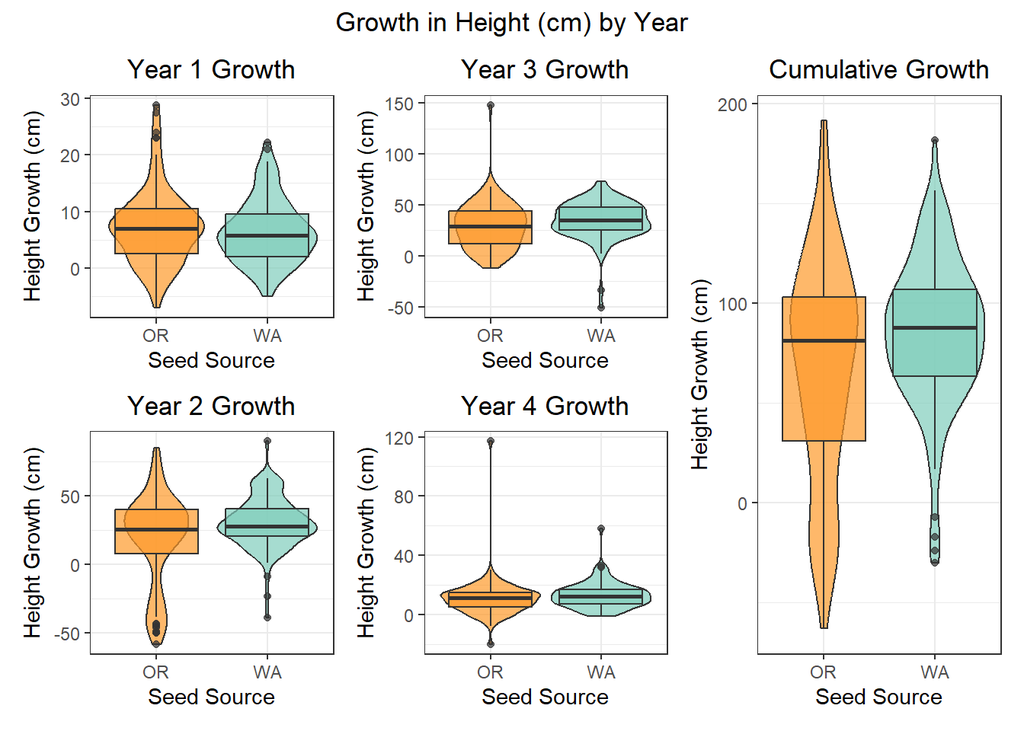

```r
P1 <- ggplot(trees.wide.growth,aes(Seed.Zone,y1.height.growth,fill=Seed.Zone)) +geom_violin(alpha=0.7) +geom_boxplot(alpha=0.7) +theme_bw()+guides(fill="none") +scale_fill_manual(values=c("#fe9929", "#7fcdbb")) +labs(y= "Height Growth (cm)", x= "Seed Source",title="Year 1 Growth") + theme(plot.title = element_text(hjust = 0.5))
P2 <- ggplot(trees.wide.growth,aes(Seed.Zone,y2.height.growth,fill=Seed.Zone)) +geom_violin(alpha=0.7) +geom_boxplot(alpha=0.7) +theme_bw()+guides(fill="none") +scale_fill_manual(values=c("#fe9929", "#7fcdbb")) +labs(y= "Height Growth (cm)",x= "Seed Source",title="Year 2 Growth") + theme(plot.title = element_text(hjust = 0.5))
P3 <- ggplot(trees.wide.growth,aes(Seed.Zone,y3.height.growth,fill=Seed.Zone)) +geom_violin(alpha=0.7) +geom_boxplot(alpha=0.7) +theme_bw()+guides(fill="none") +scale_fill_manual(values=c("#fe9929", "#7fcdbb")) +labs(y= "Height Growth (cm)",x= "Seed Source",title="Year 3 Growth") + theme(plot.title = element_text(hjust = 0.5))
P4 <- ggplot(trees.wide.growth,aes(Seed.Zone,y4.height.growth,fill=Seed.Zone)) +geom_violin(alpha=0.7) +geom_boxplot(alpha=0.7) +theme_bw()+guides(fill="none") +scale_fill_manual(values=c("#fe9929", "#7fcdbb")) +labs(y= "Height Growth (cm)",x= "Seed Source",title="Year 4 Growth") + theme(plot.title = element_text(hjust = 0.5))
P5 <- ggplot(trees.wide.growth,aes(Seed.Zone,total.height.growth,fill=Seed.Zone)) +geom_violin(alpha=0.7) +geom_boxplot(alpha=0.7) +theme_bw()+guides(fill="none") +scale_fill_manual(values=c("#fe9929", "#7fcdbb")) +labs(y= "Height Growth (cm)",x= "Seed Source",title="Cumulative Growth") + theme(plot.title = element_text(hjust = 0.5))

plots1 <-plot_grid(P1, P2, align = "v", nrow = 2, ncol = 1, rel_heights = c(1/2,1/2))
plots2 <- plot_grid(P3, P4, align = "v", nrow = 2, ncol = 1, rel_heights = c(1/2,1/2))
plots3 <- plot_grid(P5, align = "v", nrow = 1, ncol = 1, rel_heights = 1)
plots <- plots1 + plots2 + plots3
plots + plot_annotation(title = "Growth in Height (cm) by Year", theme = theme(plot.title = element_text(hjust = 0.5)))
```

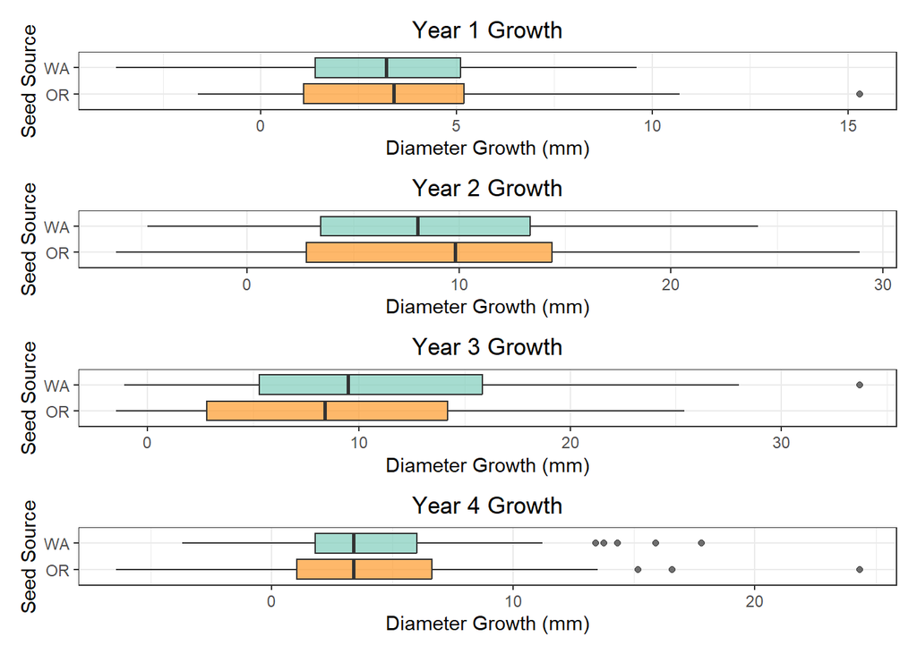

```r
G1 <- ggplot(trees.wide.growth,aes(y1.diameter.growth,Seed.Zone,fill=Seed.Zone))+geom_boxplot(alpha=0.7) +theme_bw() +guides(fill="none") +scale_fill_manual(values=c("#fe9929", "#7fcdbb")) +labs(x= "Diameter Growth (mm)",y= "Seed Source",title="Year 1 Growth") + theme(plot.title = element_text(hjust = 0.5))
G2 <- ggplot(trees.wide.growth,aes(y2.diameter.growth,Seed.Zone,fill=Seed.Zone))+geom_boxplot(alpha=0.7) +theme_bw() +guides(fill="none") +scale_fill_manual(values=c("#fe9929", "#7fcdbb")) +labs(x= "Diameter Growth (mm)",y= "Seed Source",title="Year 2 Growth") + theme(plot.title = element_text(hjust = 0.5))
G3 <- ggplot(trees.wide.growth,aes(y3.diameter.growth,Seed.Zone,fill=Seed.Zone))+geom_boxplot(alpha=0.7) +theme_bw() +guides(fill="none") +scale_fill_manual(values=c("#fe9929", "#7fcdbb")) +labs(x= "Diameter Growth (mm)",y= "Seed Source",title="Year 3 Growth") + theme(plot.title = element_text(hjust = 0.5))
G4 <- ggplot(trees.wide.growth,aes(y4.diameter.growth,Seed.Zone,fill=Seed.Zone))+geom_boxplot(alpha=0.7) +theme_bw() +guides(fill="none") +scale_fill_manual(values=c("#fe9929", "#7fcdbb")) +labs(x= "Diameter Growth (mm)",y= "Seed Source",title="Year 4 Growth") + theme(plot.title = element_text(hjust = 0.5))
G1 / G2 / G3 / G4
```

The below plots show the distributions in increases in tree height for each seed zone and site.

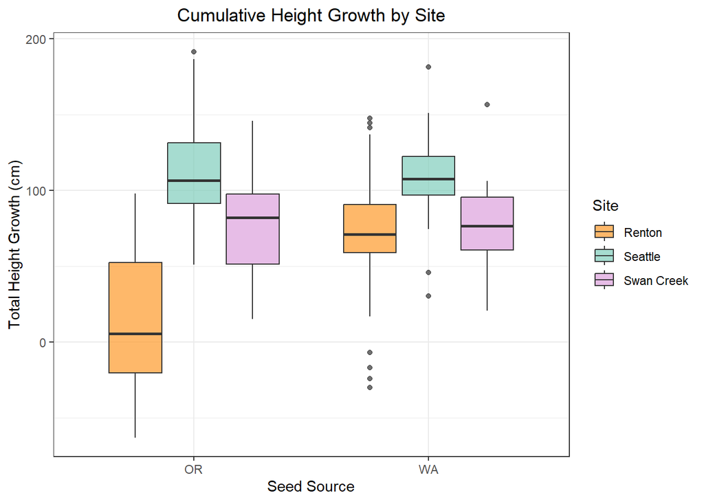

```r
ggplot(trees.wide.growth,aes(Seed.Zone,total.height.growth,fill=Site)) +geom_boxplot(alpha=0.7) +theme_bw() +scale_fill_manual(values=c("#fe9929", "#7fcdbb", "#DDA0DD","#89CFF0")) + labs(y= "Total Height Growth (cm)",x= "Seed Source",title="Cumulative Height Growth by Site") + theme(plot.title = element_text(hjust = 0.5))
```

#### Mortality

The below plots show the number of trees that fall under each Health condition: alive, dead, or missing.

- Note: Missing trees are classified as trees that were not found during re-measurements as of the most recent observation in 2026.

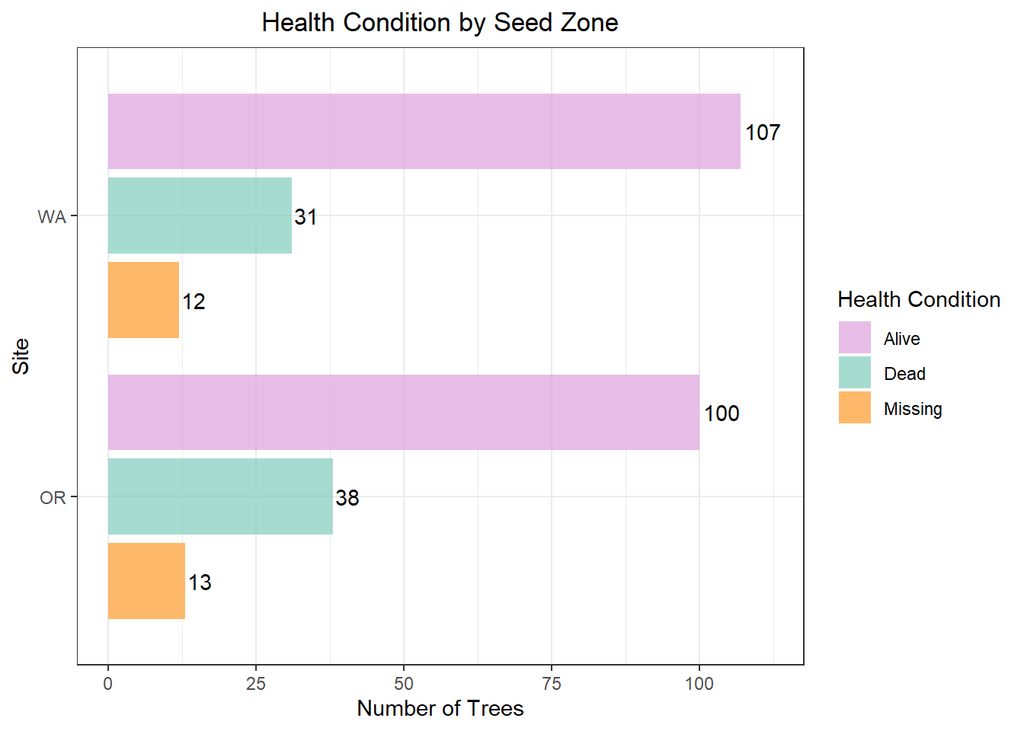

```r
trees.condition.zone <- trees %>% group_by(Seed.Zone,Final.Health) %>% filter(Site != "Tomanamus") %>% summarize(n=n_distinct(Temp.Tree.Number)) %>% filter(Final.Health!="NA")

ggplot(trees.condition.zone,aes(x = reorder(Seed.Zone, -n),n,fill=Final.Health))+geom_col(alpha=0.7,position = position_dodge2(preserve = "single",reverse=TRUE))+theme_bw()+coord_flip()+ scale_y_continuous(breaks = c(0,25,50,75,100,125,150),expand = expansion(mult = c(0.05, 0.1))) +scale_fill_manual(values=c( "#DDA0DD","#7fcdbb","#fe9929","#CC79A7"))+labs(x="Site",y="Number of Trees",title ="Health Condition by Seed Zone", fill="Health Condition") +geom_text(aes(label=n,group=Final.Health),position = position_dodge2(width=0.9,preserve = "single",reverse=TRUE),hjust=-0.1) + theme(plot.title = element_text(hjust = 0.5))
```

The below plot shows the number of trees that fall under each health condition sorted by seed zone and planting site.

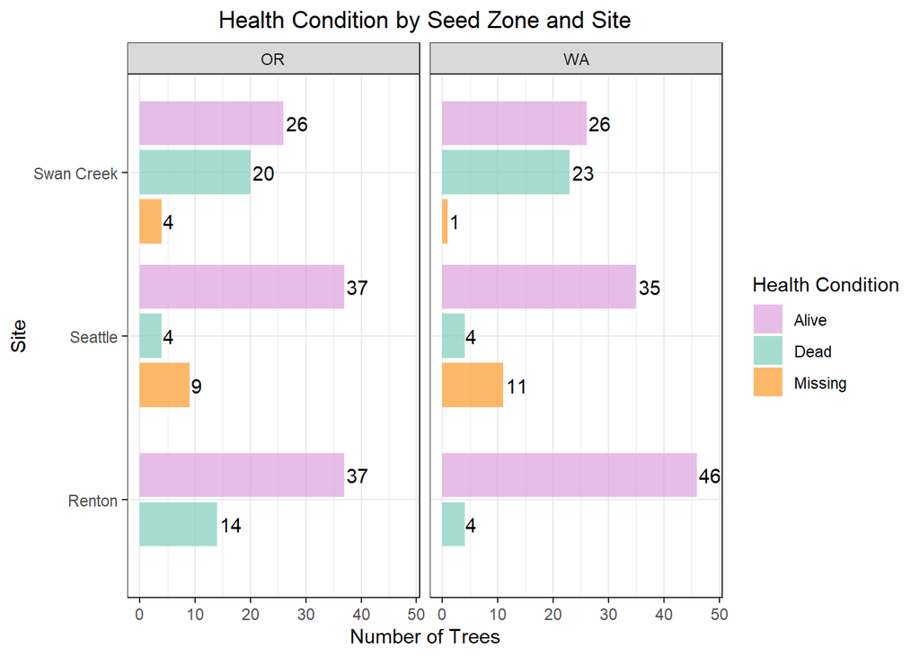

```r
trees.condition <- trees %>% group_by(Site, Seed.Zone, Final.Health) %>% summarize(n=n_distinct(Temp.Tree.Number)) %>% filter(Final.Health!="NA") %>% filter(Site != "Tomanamus")

trees.condition$Final.Health <- factor(trees.condition$Final.Health, levels=c('Alive','Dead','Dying','Missing'))

ggplot(trees.condition,aes(x = reorder(Site, -n),n,fill=Final.Health))+facet_wrap(~Seed.Zone)+geom_col(alpha=0.7,position = position_dodge2(preserve = "single",reverse=TRUE))+theme_bw()+coord_flip() + scale_y_continuous(expand = expansion(mult = c(0.05, 0.1))) +scale_fill_manual(values=c( "#DDA0DD","#7fcdbb","#fe9929","#CC79A7"))+labs(x="Site",y="Number of Trees", title = "Health Condition by Seed Zone and Site",fill="Health Condition") +geom_text(aes(label=n,group=Final.Health),position = position_dodge2(width=0.9,preserve = "single",reverse=TRUE),hjust=-0.1) + theme(plot.title = element_text(hjust = 0.5))
```

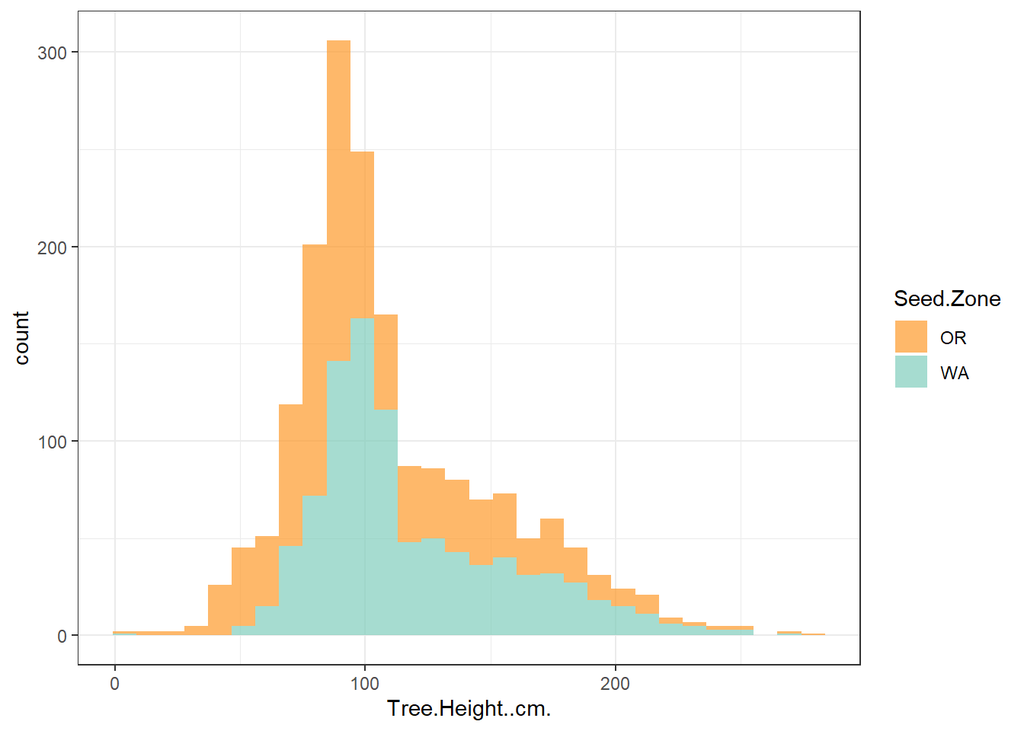

```r
ggplot(trees,aes(Tree.Height..cm.,fill=Seed.Zone))+geom_histogram(alpha=0.7) +theme_bw() +scale_fill_manual(values=c("#fe9929", "#7fcdbb"))
```

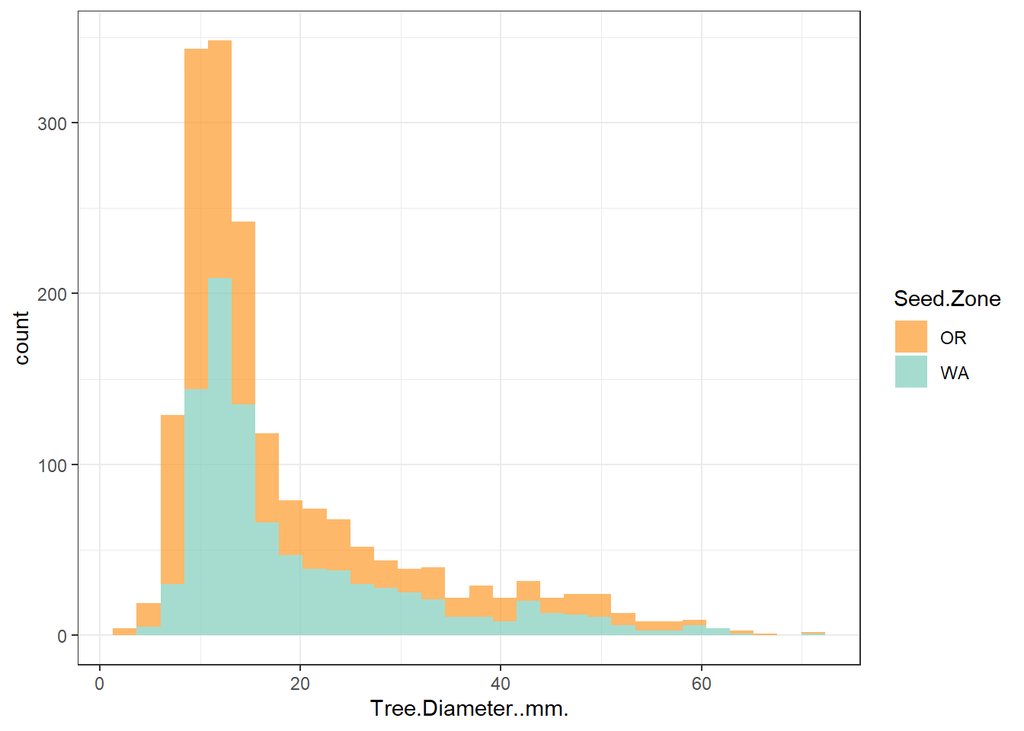

```r
ggplot(trees,aes(Tree.Diameter..mm.,fill=Seed.Zone))+geom_histogram(alpha=0.7) +theme_bw() +scale_fill_manual(values=c("#fe9929", "#7fcdbb"))
```

## Analysis

```r
growth <- trees %>%
  group_by(Tree.Number, Site, Seed.Zone) %>%
  arrange(Measurement.Year) %>%
  mutate(
    Height.Change = Tree.Height..cm. - lag(Tree.Height..cm.),
    Diameter.Change = Tree.Diameter..mm. - lag(Tree.Diameter..mm.)
  )
```

```r
growth.positive <- growth %>% filter(Height.Change>0)
```

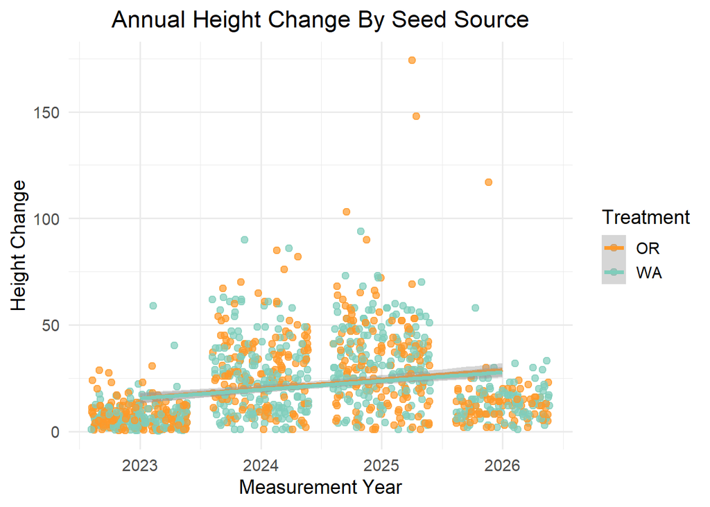

```r
ggplot(growth.positive,aes(Measurement.Year,Height.Change,color=Seed.Zone)) +  geom_point(size = 2, alpha = 0.7,position=position_jitter()) + geom_smooth(method = "lm", se = TRUE, linetype = "solid") +labs(title = "Annual Height Change By Seed Source", x = "Measurement Year", y = "Height Change",color = "Treatment") +theme_minimal(base_size = 14)  +scale_color_manual(values=c("#fe9929", "#7fcdbb")) + theme(plot.title = element_text(hjust = 0.5))
```

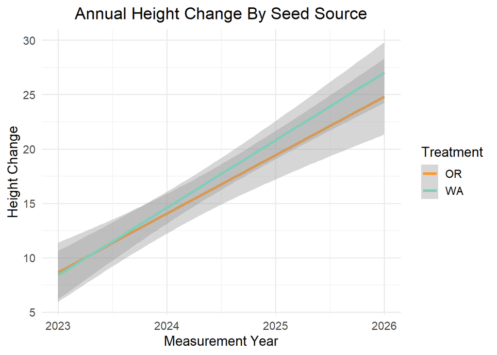

```r
ggplot(growth,aes(Measurement.Year,Height.Change,color=Seed.Zone)) + geom_smooth(method = "lm", se = TRUE, linetype = "solid") +labs(title = "Annual Height Change By Seed Source", x = "Measurement Year", y = "Height Change",color = "Treatment") +theme_minimal(base_size = 14)  +scale_color_manual(values=c("#fe9929", "#7fcdbb")) + theme(plot.title = element_text(hjust = 0.5))
```

```r
names(growth)
```

```
##  [1] "X"                   "Tree.Number"         "Site"
##  [4] "Seed.Zone"           "Measurement.Year"    "Date.Measured"
##  [7] "Tree.Height..cm."    "Tree.Diameter..mm."  "Health"
## [10] "Comment"             "Date.Planted"        "Temp.Tree.Number"
## [13] "New.Tree.Number"     "Year.Measured"       "Elk.Browse"
## [16] "Planted.Growth.Days" "Final.Health"        "Height.Change"
## [19] "Diameter.Change"
```

```r
model <- lmer(Height.Change ~ Seed.Zone + (1 | Site) + (1|Elk.Browse), data = growth)
```

```r
summary(model)
```

```
## Linear mixed model fit by REML. t-tests use Satterthwaite's method [
## lmerModLmerTest]
## Formula: Height.Change ~ Seed.Zone + (1 | Site) + (1 | Elk.Browse)
##    Data: growth
##
## REML criterion at convergence: 12036.7
##
## Scaled residuals:
##     Min      1Q  Median      3Q     Max
## -5.2102 -0.6131 -0.2098  0.5520  7.5122
##
## Random effects:
##  Groups     Name        Variance Std.Dev.
##  Site       (Intercept)  32.13    5.669
##  Elk.Browse (Intercept) 146.18   12.090
##  Residual               421.83   20.538
## Number of obs: 1354, groups:  Site, 4; Elk.Browse, 2
##
## Fixed effects:
##             Estimate Std. Error       df t value Pr(>|t|)
## (Intercept)    9.933      9.059    1.232   1.096    0.442
## Seed.ZoneWA    1.469      1.119 1348.225   1.313    0.189
##
## Correlation of Fixed Effects:
##             (Intr)
## Seed.ZoneWA -0.064
```